# Hypothesis testing for the RAS in slow wave sleep

## Aim of the notebook

To build and test a statistical model that verifies (or refutes) hypotheses about RAS in SWS.

**Hypothesis 1:** RAS will selectively increase Delta power in SWS (cond X band interaction)  
**Hypothesis 2:** RAS will selectively increase Delta power in the targeted hemisphere (cond X band X side interaction)  
**Expected findings:** In SWS, EEG power bands should have a maked difference: Delta and Theta should be increased, while Beta, Alpha and Sigma should be decreased

```r
ras <- read_csv("ras_data.csv") %>%
    set_names(names(.) %>% str_to_lower()) %>%
    mutate(cond = fct_relevel(cond, c("SILENT","RAS")),
           side = fct_relevel(side, c("Untargeted","Targeted")),
           origin = if_else(str_detect(id, "^\\d{2}-.*"), "old", "new"),
           sex = if_else(str_detect(id, "^.*-.*-M.*"), "male", "female"), # Last 7 is not correct!
           value_log = log(value +1)
           ) %>%
    group_by(id) %>%
    mutate(value_std = scale(value_log) %>% as.numeric()) %>%
    ungroup()
```

# Model building

First, we compare a model that does not account for individual variability.

```r
# Create a model that ignores the dependence in data, and use all possible variable combinations
ras_lm <- lm(value ~ cond*band*side, data = ras)
```

## Before we continue, we should investigate the effect of the trials.

The histograms show that most of the participants have about 20 trials. Only a few participants have more then 60 trials. This is not a problem if the trials exert the same effect on the EEG spectra. However, it seems like the trials do have an effect on the EEG, so we will need to include this in the model.

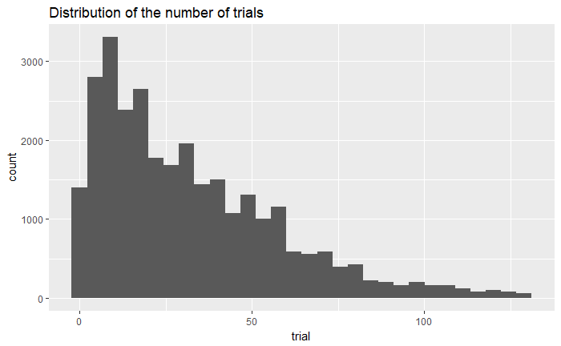

```r
ggplot(ras) +
    aes(x = trial) +
    geom_histogram() +
    ggtitle("Distribution of the number of trials")
```

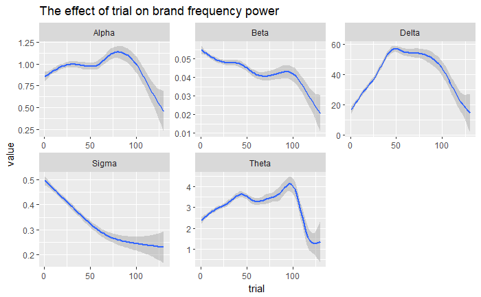

```r
ras %>%
    ggplot() +
    aes(x = trial, y = value) +
    geom_smooth() +
    facet_wrap(~band, scales = "free") +
    ggtitle("The effect of trial on brand frequency power")
```

# Finding the random structure

Based on the model comparisons, it seems like the random intercept model has an adventage over the linear regression without random terms. However, the random slope model does not seem to increase the model fit.

```r
# Model with random intercept
ras_lmer_i <- lmer(value_log ~ cond*band*side + (1|id) + (1|trial), data = ras)
# Model with random intercept and slope
ras_lmer_is <- lmer(value_log ~ cond*band*side + (cond|id) + (cond|trial), data = ras)
anova(ras_lmer_i, ras_lm)
```

```
refitting model(s) with ML (instead of REML)
```

```
Data: ras
Models:
..1: value ~ cond * band * side
object: value_log ~ cond * band * side + (1 | id) + (1 | trial)
       Df    AIC    BIC  logLik deviance  Chisq Chi Df Pr(>Chisq)
..1    21 243303 243478 -121631   243261
object 23  27052  27243  -13503    27006 216255      2  < 2.2e-16 ***
---
Signif. codes:  0 ‘***’ 0.001 ‘**’ 0.01 ‘*’ 0.05 ‘.’ 0.1 ‘ ’ 1
```

```r
anova(ras_lmer_i, ras_lmer_is)
```

```
refitting model(s) with ML (instead of REML)
```

```
Data: ras
Models:
object: value_log ~ cond * band * side + (1 | id) + (1 | trial)
..1: value_log ~ cond * band * side + (cond | id) + (cond | trial)
       Df   AIC   BIC logLik deviance  Chisq Chi Df Pr(>Chisq)
object 23 27052 27243 -13503    27006
..1    27 27057 27281 -13501    27003 3.7095      4     0.4468
```

# Evaluate the model

However, there we fonund no significant 3-way interactions, i.e. there is no evidence of a selective change in bandpower during the RAS in the targeted hemisphere. Therefore hypothesis 2 could not be verified.

Also, as expected, the band main effects were significant during sleep: delta and theta power was higher, while beta and sigma power was lower (compared to alpha activity that was used as baseline).

```r
# Retrain the model with standardised coefficients
summary(ras_lmer_i)
```

```
Linear mixed model fit by REML t-tests use Satterthwaite approximations to degrees of  freedom
 [lmerMod]
Formula: value_log ~ cond * band * side + (1 | id) + (1 | trial)
   Data: ras

REML criterion at convergence: 27148.1

Scaled residuals:
    Min      1Q  Median      3Q     Max
-6.0243 -0.5345 -0.0219  0.5150  5.2141

Random effects:
 Groups   Name        Variance Std.Dev.
 trial    (Intercept) 0.002103 0.04586
 id       (Intercept) 0.077618 0.27860
 Residual             0.144282 0.37985
Number of obs: 29570, groups:  trial, 130; id, 35

Fixed effects:
                                 Estimate Std. Error         df t value Pr(>|t|)
(Intercept)                     5.914e-01  4.844e-02  3.800e+01  12.210 1.15e-14 ***
condRAS                        -7.008e-03  1.397e-02  2.942e+04  -0.502 0.616006
bandBeta                       -5.917e-01  1.395e-02  2.942e+04 -42.401  < 2e-16 ***
bandDelta                       2.661e+00  1.395e-02  2.942e+04 190.733  < 2e-16 ***
bandSigma                      -3.186e-01  1.395e-02  2.942e+04 -22.830  < 2e-16 ***
bandTheta                       6.727e-01  1.395e-02  2.942e+04  48.208  < 2e-16 ***
sideTargeted                   -3.105e-02  1.395e-02  2.942e+04  -2.225 0.026090 *
condRAS:bandBeta               -5.050e-03  1.976e-02  2.942e+04  -0.256 0.798254
condRAS:bandDelta               7.298e-02  1.976e-02  2.942e+04   3.694 0.000222 ***
condRAS:bandSigma              -1.007e-02  1.976e-02  2.942e+04  -0.510 0.610167
condRAS:bandTheta               6.210e-03  1.976e-02  2.942e+04   0.314 0.753281
condRAS:sideTargeted           -2.978e-04  1.976e-02  2.942e+04  -0.015 0.987973
bandBeta:sideTargeted           2.825e-02  1.973e-02  2.942e+04   1.431 0.152330
bandDelta:sideTargeted         -2.029e-02  1.973e-02  2.942e+04  -1.028 0.303800
bandSigma:sideTargeted          2.153e-02  1.973e-02  2.942e+04   1.091 0.275307
bandTheta:sideTargeted         -8.478e-03  1.973e-02  2.942e+04  -0.430 0.667464
condRAS:bandBeta:sideTargeted   6.095e-04  2.794e-02  2.942e+04   0.022 0.982597
condRAS:bandDelta:sideTargeted  5.257e-03  2.794e-02  2.942e+04   0.188 0.850774
condRAS:bandSigma:sideTargeted  7.393e-04  2.794e-02  2.942e+04   0.026 0.978892
condRAS:bandTheta:sideTargeted  7.247e-03  2.794e-02  2.942e+04   0.259 0.795356
---
Signif. codes:  0 ‘***’ 0.001 ‘**’ 0.01 ‘*’ 0.05 ‘.’ 0.1 ‘ ’ 1
```

```
Correlation matrix not shown by default, as p = 20 > 12.
Use print(x, correlation=TRUE)  or
     vcov(x)     if you need it
```

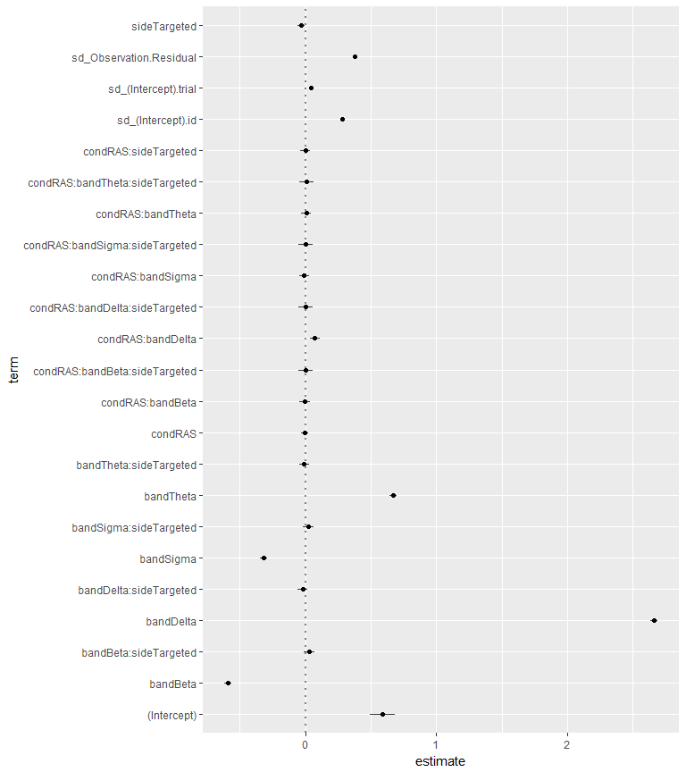

```r
GGally::ggcoef(ras_lmer_i)
```

# Investigate the residuals

The residual plots indicate that the residuals are not exactly normally distributed. However, the distribution of residuals is symmetrical, and unimodal. Data is not normal because the distribution seems to have a higher kurtosis, compared to normal distribution. In my opinion, this difference does not seem to be problematic.

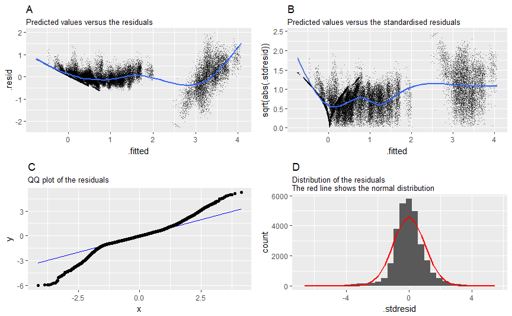

```r
diag_data <-
    augment(ras_lmer_i, ras) %>%
    mutate(.stdresid = scale(.resid) %>% as.numeric())
plot_1 <- ggplot(diag_data) +
    aes(x = .fitted, y = .resid) +
    geom_point(alpha = .5, shape = ".") +
    geom_smooth() +
    ggtitle("A",subtitle = "Predicted values versus the residuals")
plot_2 <- ggplot(diag_data) +
    aes(x = .fitted, y = sqrt(abs(.stdresid))) +
    geom_point(alpha = .5, shape = ".") +
    geom_smooth() +
    ggtitle("B", subtitle = "Predicted values versus the standardised residuals")
    # labs(x = "\\sqrt{/residual/}", parse = TRUE)
plot_3 <- ggplot(diag_data) +
    aes(sample = .stdresid) +
    geom_qq_line(color = "blue") +
    geom_qq() +
    ggtitle("C", subtitle = "QQ plot of the residuals")
plot_4 <- ggplot(diag_data) +
    aes(x = .stdresid) +
    geom_histogram(bins = 30) +
    geom_freqpoly(data = rnorm(nrow(diag_data), 0, 1) %>% data_frame(x = .), aes(x = x), color = "red", size = 1) +
    ggtitle("D",subtitle = "Distribution of the residuals\nThe red line shows the normal distribution")
gridExtra::grid.arrange(plot_1, plot_2, plot_3, plot_4)
```

# Explained variance

We can calculate the R squared for the fixed effects only (marginal R2), and adding the random terms (conditional R2). It seems like that the model explain a large portion of the variance, however it is sure that the biggest portion is explained by the band main effect.

```r
MuMIn::r.squaredGLMM(ras_lmer_i)
```

```
      R2m       R2c
0.8603665 0.9100609
```

# Conclusion

The verification of hypothesis 1 supports the idea that 4 Hz RAS can selectively increase delta bandpower in slow-wave sleep. On the other hand, we could not support hypothesis 2 which asserted that it is possible to selectively increase Delta power in the targeted hemisphere.